# HW1 Programming Problem 4 (30 points)

## Problem Description

In this problem you will implement gradient descent on the following function: $f(x) = x^2 + 3x +6\textrm{sin}(x)$. You will define your own gradient function $\texttt{fgrad}(x)$, and then using the provided learning rate $\eta = 0.15$ and initial guess $x_0 = 8$, you will print the value of $x$ and $f(x)$ for the first 10 iterations.

Fill out the notebook as instructed, making the requested plots and printing necessary values.

#### Summary of deliverables:

Functions:

- `fgrad(x)`

Results:

- Printed values of $x$ and $f(x)$ for the first 10 iterations of gradient descent

Discussion:

- Do your printed values appear to be converging towards the minimum of the function?

Imports and provided functions:

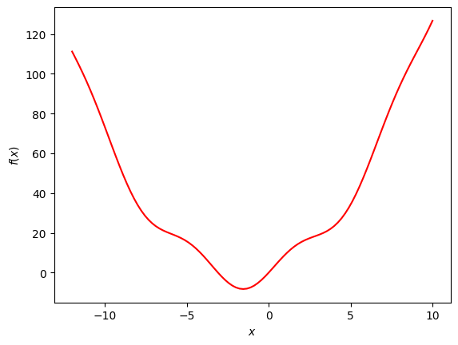

```python
import numpy as np
import matplotlib.pyplot as plt

def f(x):
    return x**2 + 3*x + 6*np.sin(x)

def plotfx():
    # Sample function
    xs = np.linspace(-12,10,100)
    ys = f(xs)
    # Plot function
    plt.plot(xs,ys,'r-')
    plt.xlabel('$x$')
    plt.ylabel('$f(x)$')
    plt.show()

# Visualize the function
plotfx()
```

### First define the function $\texttt{fgrad}(x)$

```python
def fgrad(x):
    return 2*x + 3 + 6*np.cos(x)
```

### Fill in the following code with the gradient descent update rule

For reference, your 10th iteration should have $x = -1.554$ and $f(x) = -8.246$

```python
iter = 10
eta = 0.15
x = 8

for i in range(iter):
    x = x - eta*fgrad(x)


    print('Iteration %d, x = %.3f, f(x) = %.3f' %(i+1, x, f(x)))
```

```
Iteration 1, x = 5.281, f(x) = 38.675
Iteration 2, x = 2.762, f(x) = 18.138
Iteration 3, x = 2.319, f(x) = 16.734
Iteration 4, x = 1.786, f(x) = 14.410
Iteration 5, x = 0.993, f(x) = 8.988
Iteration 6, x = -0.247, f(x) = -2.147
Iteration 7, x = -1.496, f(x) = -8.233
Iteration 8, x = -1.565, f(x) = -8.246
Iteration 9, x = -1.551, f(x) = -8.246
Iteration 10, x = -1.554, f(x) = -8.246
```

### Briefly discuss whether your printed values of $x$ and $f(x)$ appear to have converged to the minimum of the function.

Feel free to refer to the provided plot of $f(x)$ above

The values do seem to have converged on the minimum because the function output for the last 3 iterations is exactly the same to at least the first 4 significant figures. In addition, the x value appears to be where we would expect it to be looking at the plot and assessign the minimum visually.